# Phân tích và dự đoán xác suất kết thúc session từ dữ liệu clickstream

Nghi, Như và Quang

26/07/2026

# 1 Giới thiệu chung và đề xuất phân tích

## 1.1 Bộ dữ liệu

Bộ dữ liệu **e-shop clothing 2008** ghi nhận hành vi click trên một cửa hàng quần áo trực tuyến. Mỗi dòng là một click; các click có cùng `session_id` tạo thành một phiên và `order` là vị trí click trong phiên. Dữ liệu kéo dài từ 01/04/2008 đến 13/08/2008.

Theo tài liệu mô tả đi kèm, dữ liệu được sử dụng trong nghiên cứu của Łapczyński và Białowąs (2013) về hành vi người dùng trong cửa hàng trực tuyến.

Tổng quan bộ dữ liệu

| Chỉ tiêu | Giá trị |
| --- | --- |
| Số click | 165.474 |
| Số session | 24.026 |
| Số quốc gia/mã miền | 47 |
| Số sản phẩm | 217 |
| Số danh mục | 4 |
| Khoảng thời gian | 01/04/2008 – 13/08/2008 |
| Tỷ lệ Continue | 85,48% |
| Tỷ lệ Exit | 14,52% |

Dữ liệu có quy mô lớn, có cấu trúc tuần tự theo session và kết hợp biến liên tục với biến phân loại. Tuy nhiên, dữ liệu không chứa giao dịch, giỏ hàng, giờ click hoặc thời lượng giữa hai click. Tháng 8 chỉ có dữ liệu đến ngày 13 và ngày 13 chỉ có 200 click, nên không thể so sánh tổng lưu lượng tháng 8 trực tiếp với các tháng đầy đủ.

## 1.2 Từ điển biến và target

Từ điển biến và vai trò trong phân tích

| Biến | Ý nghĩa | Vai trò |
| --- | --- | --- |
| year, month, day | Ngày lịch; không có giờ hoặc thời lượng | Tạo time_30; year bị loại vì không biến thiên |
| order | Thứ tự click trong session | Predictor, dùng log2(order) hoặc hàm trơn |
| country | Quốc gia hoặc loại tên miền của IP | Predictor factor; mức hiếm được gộp trên train |
| session_id | Mã session | Nhóm dữ liệu và tính robust SE; không làm predictor |
| category | PAGE 1: trousers, skirts, blouses hoặc sale | Predictor factor |
| product_model | PAGE 2: mã của 217 sản phẩm | Không đưa vào mô hình chính do có 217 mức |
| colour | Màu sản phẩm | Predictor factor |
| location | Vị trí ảnh trong sáu vùng của trang; không phải địa lý | Predictor factor |
| photography | Kiểu ảnh en face hoặc profile | Predictor factor |
| price | Giá sản phẩm, USD | Predictor liên tục |
| price_above_avg | 1 = cao hơn trung bình danh mục; 2 = không | Tạo hai nhóm cho kiểm định; không dùng cùng price trong mô hình A/B |
| page | Trang hiển thị trong website, từ 1 đến 5 | Predictor factor |

Target thống nhất cho các mô hình xác suất là:

$$Exit_{it} =
\begin{cases}
1, & \text{click hiện tại là click cuối session;}\\
0, & \text{session còn click tiếp theo.}
\end{cases}$$

`session_length` chỉ được dùng để tạo target và không được đưa vào predictor vì đây là thông tin tương lai. Xác suất được nghiên cứu là xác suất nguy cơ rời rạc:

$$P\{Exit_{it}=1\mid \text{session đã tiếp tục đến click }t\}.$$

Tại `order = t`, mẫu số chỉ gồm các session đã tồn tại đến click $t$. Vì vậy, kết quả theo `order` là quan hệ có điều kiện, không phải bằng chứng rằng tăng số click gây ra thay đổi nguy cơ kết thúc.

## 1.3 Mục tiêu phân tích

1. **So sánh hai nhóm dạng A/B:** kiểm tra xác suất `Exit` có khác giữa sản phẩm có giá cao hơn trung bình danh mục và sản phẩm không cao hơn trung bình hay không.
2. **Phân tích yếu tố liên quan đến `Exit`:** mô tả quan hệ với tiến trình session; đánh giá thông tin bổ sung của đặc điểm click hiện tại và lịch sử duyệt đã quan sát.
3. **Xây dựng và so sánh mô hình:** so sánh Linear Probability Model (LPM), Logistic GLM và Binomial GAM về phân biệt, chất lượng xác suất, calibration và khả năng diễn giải.

Phân nhóm giá không được gán ngẫu nhiên. Do đó, Mục tiêu 1 là một so sánh hai nhóm **dạng A/B trên dữ liệu quan sát**, không phải thí nghiệm A/B có treatment/control. Kết luận chỉ phản ánh mối liên hệ.

## 1.4 Chiến lược phân tích

Chia dữ liệu theo thời gian

| Tập | Thời gian | Số click | Số session |
| --- | --- | --- | --- |
| Train | Tháng 4–6 | 116.095 | 17.031 |
| Validation | Tháng 7 | 35.231 | 5.071 |
| Temporal test | 01–12/08 | 13.948 | 1.903 |
| Loại khỏi đánh giá | 13/08 | 200 | 21 |

Mọi quy tắc tiền xử lý được học trên train. Các country có dưới 100 click train được gộp thành `Other`; cùng quy tắc được áp dụng cho validation và temporal test. Không có session nào xuất hiện đồng thời trong hai tập bất kỳ.

Ba tầng predictor được so sánh: baseline dùng `log2(order) + time_30 + country`; current-click thêm đặc điểm sản phẩm hiện tại; history-enhanced thêm số sản phẩm/danh mục đã xem, chuyển trang/danh mục, quay lại sản phẩm và thay đổi giá so với lịch sử. Mọi history feature tại click $t$ chỉ dùng dữ liệu từ click 1 đến $t$. LPM và Logistic GLM dùng cluster-robust covariance theo `session_id`; GAM dùng link logit và các hàm trơn.

Đánh giá xác suất dựa trên ROC–AUC, Average Precision, log loss, Brier score, Brier Skill Score và calibration. Threshold tối đa F1 được chọn từ prediction out-of-fold của five-fold CV theo session. Tháng 7 dùng để so sánh đặc tả và chọn mô hình; ngày 01–12/08 là temporal test cuối cùng, không tham gia chọn mô hình hoặc threshold.

# 2 Khám phá và tổng hợp dữ liệu

## 2.1 Kiểm tra chất lượng dữ liệu

Kết quả kiểm tra chất lượng dữ liệu

| Kiểm tra | Số trường hợp vi phạm |
| --- | --- |
| Giá trị khuyết thiếu | 0 |
| Dòng trùng hoàn toàn | 0 |
| Session có order không liên tục | 0 |
| Session không có đúng một Exit | 0 |
| Session xuất hiện ở cả train và test | 0 |

Không phát hiện missing value, dòng trùng hoặc lỗi trình tự. Các session dài không bị xóa chỉ vì nằm ngoài râu boxplot: chúng có trình tự hợp lệ và có thể phản ánh hành vi duyệt dài. `log2(order)` và GAM được dùng để giảm ảnh hưởng của đuôi phải mà không loại dữ liệu hợp lệ.

## 2.2 Thống kê mô tả

Phân phối `order` trên toàn bộ click và phân phối độ dài ở cấp session trả lời hai câu hỏi khác nhau. Vì session dài đóng góp nhiều click hơn, không được dùng trung vị `order` trên click để kết luận trực tiếp về một session điển hình.

Thống kê mô tả biến định lượng

| Biến | Đơn vị phân tích | N | Mean | Median | Q1 | Q3 | Min | Max | SD |
| --- | --- | --- | --- | --- | --- | --- | --- | --- | --- |
| Price | Click | 165.474 | 43.80 | 43 | 33 | 52 | 18 | 82 | 12.55 |
| Order | Click | 165.474 | 9.82 | 6 | 2 | 12 | 1 | 195 | 13.48 |
| Session length | Session | 24.026 | 6.89 | 4 | 2 | 8 | 1 | 195 | 9.00 |

Giá chỉ nhận 20 mức từ 18 đến 82 USD nên có dạng rời rạc và nhiều đỉnh; mean gần median không đủ để kết luận phân phối chuẩn. Độ dài session có trung vị 4 click, trong khi 2,48% session dài hơn 30 click và 0,071% dài hơn 100 click.

Phân phối các biến phân loại chính

| Nhóm | Số click | Biến | Tỷ lệ |
| --- | --- | --- | --- |
| Trousers | 49.742 | Category | 30,06% |
| Skirts | 38.408 | Category | 23,21% |
| Blouses | 38.577 | Category | 23,31% |
| Sale | 38.747 | Category | 23,42% |
| Top left | 34.532 | Location | 20,87% |
| Top middle | 33.383 | Location | 20,17% |
| Top right | 21.656 | Location | 13,09% |
| Bottom left | 27.377 | Location | 16,54% |
| Bottom middle | 27.783 | Location | 16,79% |
| Bottom right | 20.743 | Location | 12,54% |
| En face | 122.439 | Photography | 73,99% |
| Profile | 43.035 | Photography | 26,01% |
| A: Không cao hơn TB | 80.779 | Price group | 48,82% |
| B: Cao hơn TB | 84.695 | Price group | 51,18% |
| Page 1 | 93.452 | Page | 56,48% |
| Page 2 | 41.037 | Page | 24,80% |
| Page 3 | 19.301 | Page | 11,66% |
| Page 4 | 8.861 | Page | 5,35% |
| Page 5 | 2.823 | Page | 1,71% |

Hai nhóm giá gần cân bằng, thuận lợi cho việc ước lượng chênh lệch với độ chính xác tốt. Tuy nhiên, cân bằng về số lượng không biến dữ liệu quan sát thành một thí nghiệm ngẫu nhiên.

## 2.3 Trực quan hóa dữ liệu

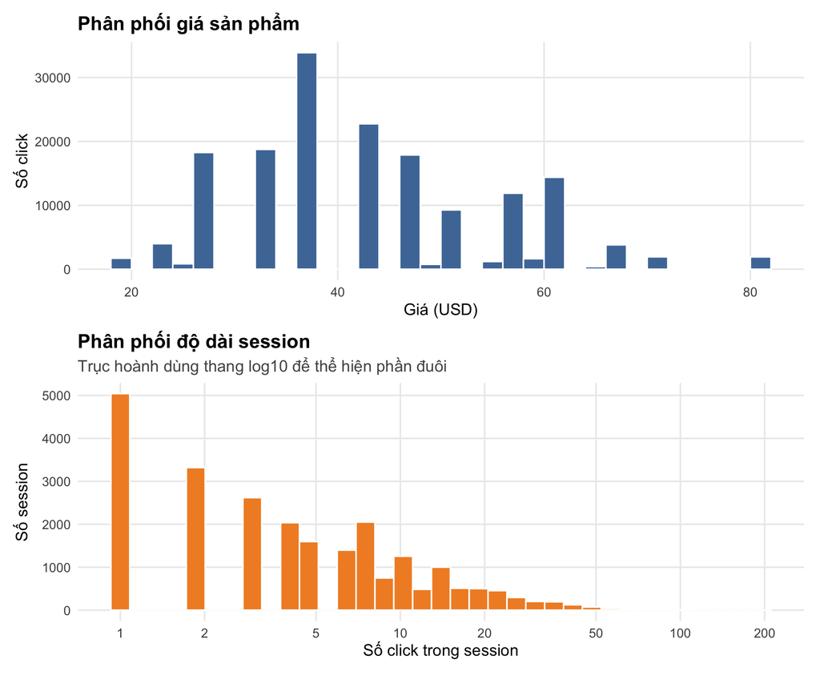

Phân phối giá phản ánh các mức giá rời rạc của danh mục sản phẩm. Phân phối độ dài session lệch phải mạnh: phần lớn session ngắn, nhưng một tỷ lệ nhỏ tiếp tục rất lâu. Đây là lý do sử dụng `log2(order)` trong LPM/Logistic và hàm trơn trong GAM thay vì xóa phần đuôi.

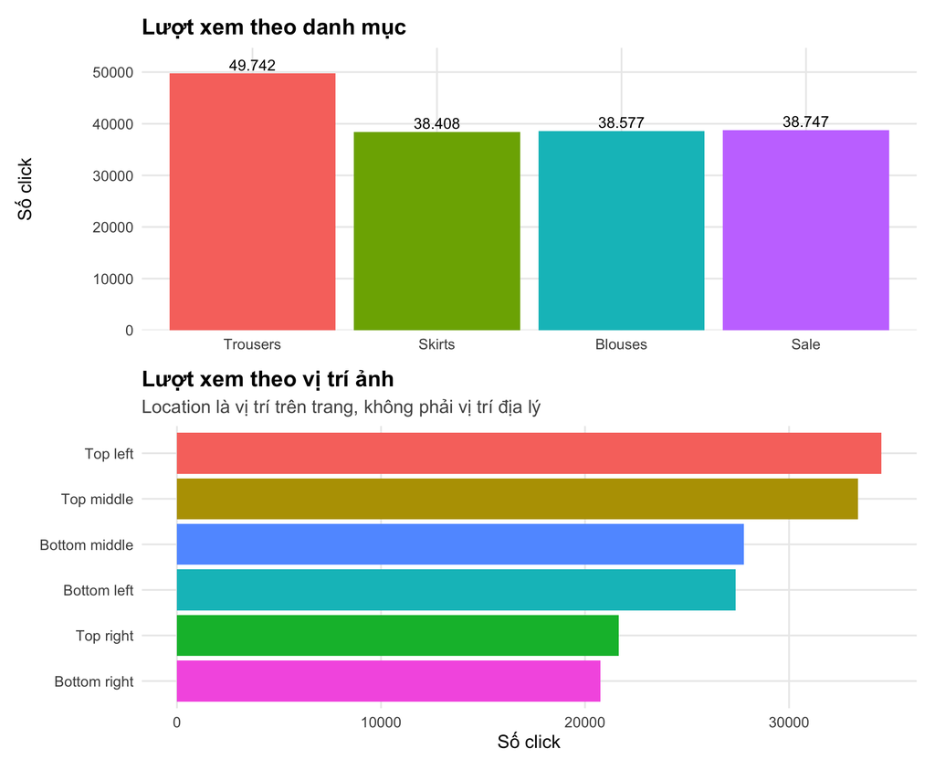

Trousers có số click cao hơn ba danh mục còn lại; đây là mô tả lưu lượng xem, không đủ để kết luận danh mục này gây thu hút hoặc tạo chuyển đổi. Các vị trí ảnh cũng có tần số khác nhau nhưng từng mã sản phẩm chỉ xuất hiện tại một vị trí, nên khác biệt vị trí có thể bị confounding bởi sản phẩm.

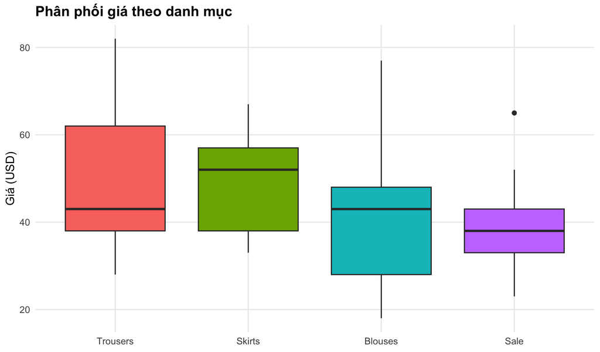

Mức giá khác rõ giữa các danh mục. Vì `price_above_avg` được xác định theo trung bình của chính danh mục, phân tích hai nhóm giá cần kiểm soát `category` và không được xem nhóm giá là một treatment được random hóa.

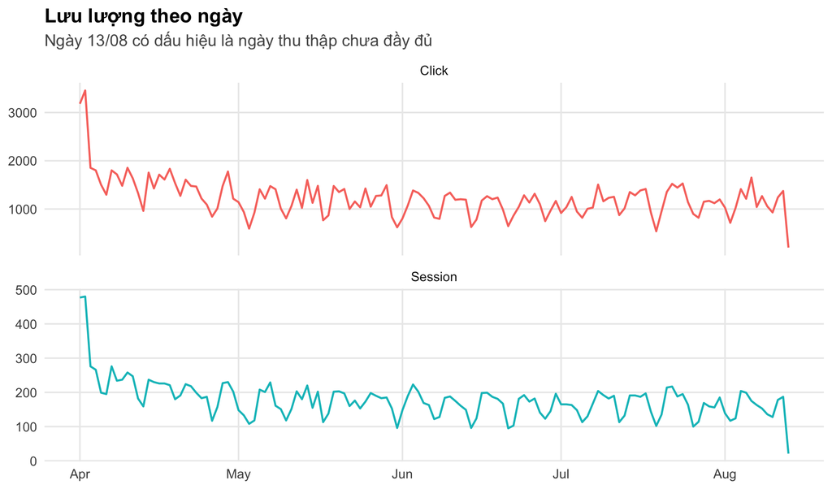

Biến động ngày cho thấy cần chia dữ liệu theo thời gian. Tổng tháng 8 thấp chủ yếu vì dữ liệu chỉ kéo dài đến ngày 13, không phải bằng chứng về suy giảm lưu lượng của cả tháng.

# 3 Kết quả phân tích và mô hình hóa

## 3.1 Kiểm định hai nhóm giá dạng A/B

Giả thuyết hai phía tại mức ý nghĩa $\alpha=0{,}05$:

$$H_0: P(Exit=1\mid A)=P(Exit=1\mid B),
\qquad
H_1: P(Exit=1\mid A)\ne P(Exit=1\mid B).$$

Trong đó A là click vào sản phẩm không có giá cao hơn trung bình danh mục và B là click vào sản phẩm có giá cao hơn trung bình danh mục.

### 3.1.1 Các đại lượng báo cáo

Với $x_g$ lượt `Exit` trong $n_g$ click của nhóm $g$, tỷ lệ quan sát là $\hat p_g=x_g/n_g$. Hai thước đo hiệu ứng chính gồm:

$$RD=\hat p_B-\hat p_A,\qquad
OR=\frac{\hat p_B/(1-\hat p_B)}{\hat p_A/(1-\hat p_A)}.$$

`RD` được diễn giải trực tiếp theo điểm phần trăm; $OR>1$ nghĩa là odds `Exit` ở B cao hơn A. Để kiểm soát khác biệt sẵn có giữa hai nhóm, báo cáo còn ước lượng mô hình
$$\operatorname{logit}\{P(Exit_i=1)\}
=\beta_0+\beta_1B_i+\boldsymbol{\gamma}^{T}X_i,$$
trong đó $\exp(\beta_1)$ là adjusted OR; adjusted RD là trung bình chênh lệch xác suất dự đoán khi lần lượt đặt mọi quan sát vào B và A. Suy luận chính cho adjusted OR/RD dùng sai số chuẩn cluster-robust theo session vì các click cùng session không độc lập; Wilson CI và kiểm định hai tỷ lệ thô chỉ có vai trò mô tả theo click. CI của RD chứa 0 hoặc CI của OR chứa 1 cho thấy chưa đủ bằng chứng về khác biệt ở mức 5%; p-value không phản ánh độ lớn thực tế của hiệu ứng.

Tỷ lệ Exit theo nhóm giá trên tập test tháng 7

| Nhóm | Click | Session | Exit | Tỷ lệ Exit | CI 95% |
| --- | --- | --- | --- | --- | --- |
| A: Không cao hơn TB | 16.879 | 4.147 | 2.325 | 13,77% | 13,26% – 14,30% |
| B: Cao hơn TB | 18.352 | 4.249 | 2.746 | 14,96% | 14,45% – 15,49% |

Chênh lệch thô B–A trên tháng 7 là 1,19 điểm phần trăm, với cluster-bootstrap CI 95% từ 0,46 đến 1,93 điểm phần trăm. Kiểm định hai tỷ lệ cho $\chi^2=$ 10,08 và $p$ 0,002.

Sau khi điều chỉnh tiến trình session, thời gian, country và các đặc điểm sản phẩm, odds ratio của nhóm B so với A là 1,071 (robust CI 95%: 1,002–1,144, $p$ 0,043). Chênh lệch xác suất đã chuẩn hóa là 0,82 điểm phần trăm (robust CI 95%: 0,03– 1,62).

Một session có thể xem sản phẩm thuộc cả hai nhóm giá, nên số session ở hai hàng không cộng thành tổng số session. Kiểm định hai tỷ lệ thô chỉ có vai trò mô tả; kết luận suy luận chính dựa trên Logistic GLM với covariance theo cụm session và cluster bootstrap.

### 3.1.2 Balance và dị biệt hiệu ứng

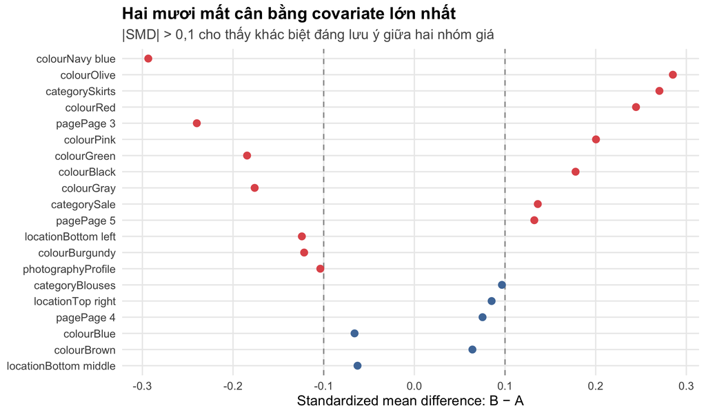

Balance diagnostics xác nhận hai nhóm không tương đương như trong một thí nghiệm random hóa. Vì vậy adjusted risk difference và robust inference được ưu tiên hơn chênh lệch thô, nhưng residual confounding vẫn có thể tồn tại.

Joint robust Wald test cho tương tác `price group × Category` có $p$ 0,051.

Adjusted risk difference của nhóm giá theo Category

| Category | N | Adjusted RD (điểm %) | CI 95% | p-value Holm |
| --- | --- | --- | --- | --- |
| Trousers | 10.871 | 2,32 | 0,86 – 3,78 | 0,008 |
| Skirts | 7.382 | 0,69 | -1,25 – 2,62 | 1,000 |
| Blouses | 7.858 | 0,72 | -0,88 – 2,33 | 1,000 |
| Sale | 9.120 | -0,66 | -2,17 – 0,85 | 1,000 |

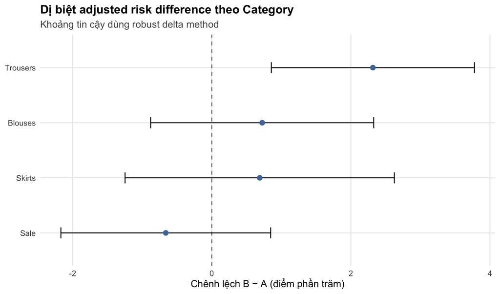

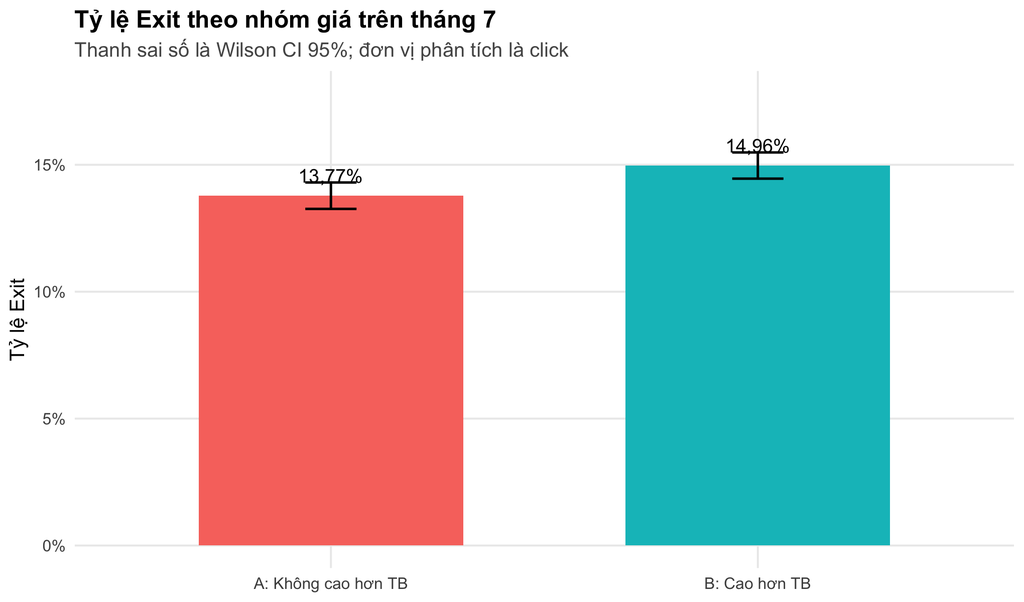

Độ ổn định theo thời gian của khác biệt giữa hai nhóm giá

| Giai_đoạn | Chênh lệch B–A (điểm %) | OR điều chỉnh | CI 95% | p-value |
| --- | --- | --- | --- | --- |
| Train: tháng 4–6 | 0,78 | 1,066 | 1,032 – 1,102 | < 0,001 |
| Phân tích chính: tháng 7 | 1,19 | 1,108 | 1,044 – 1,175 | < 0,001 |
| Kiểm tra thời gian: 01–12/08 | 1,36 | 1,125 | 1,021 – 1,240 | 0,017 |

Để so sánh nhất quán giữa các giai đoạn, OR trong bảng độ ổn định chỉ điều chỉnh `log2(Order)`, thời gian và country. Mô hình A/B chính ở tháng 7 còn điều chỉnh thêm các đặc điểm sản phẩm và vì vậy cho OR thận trọng hơn.

Khác biệt có cùng chiều trong train, tháng 7 và đầu tháng 8. Tuy nhiên, `price_above_avg` là thuộc tính sản phẩm chứ không phải treatment được gán ngẫu nhiên. Kết quả cho thấy mối liên hệ ổn định theo thời gian, nhưng không chứng minh việc tăng giá gây ra `Exit`.

### 3.1.3 Đề xuất một A/B test ngẫu nhiên thực sự

Một thí nghiệm tiếp theo nên randomize ở cấp session, lưu `experiment_id` và giữ mỗi session trong đúng một treatment. Thay vì tự ý thay đổi giá sản phẩm, treatment khả thi hơn là cách trình bày thông tin giá hoặc thông điệp giá trị:

- **Control:** giao diện giá hiện tại.
- **Treatment:** bổ sung thông điệp giá trị/ưu đãi vận chuyển, với giá sản phẩm không đổi.
- **Primary outcome:** tỷ lệ session kết thúc trong một cửa sổ click được xác định trước; secondary outcomes gồm session length và số sản phẩm duy nhất.
- **Phân tích:** intention-to-treat, hai phía, $\alpha=0{,}05$, không dừng sớm dựa trên p-value chưa điều chỉnh.

Không báo cáo một cỡ mẫu giả chính xác từ hai tỷ lệ click quan sát ở trên vì thí nghiệm tương lai randomize theo session và có estimand khác. Trước khi tính power cần khóa cửa sổ outcome, tỷ lệ nền ở cấp session, minimum detectable effect và mức hao hụt; cỡ mẫu sau đó được tính trực tiếp theo số session mỗi nhóm.

## 3.2 LPM, Logistic GLM và Binomial GAM

### 3.2.1 Xác suất Exit theo tiến trình session

Tỷ lệ Exit gộp theo khoảng Order trên tháng 7

| Khoảng Order | Click có nguy cơ | Click kết thúc | Tỷ lệ Exit gộp | CI 95% |
| --- | --- | --- | --- | --- |
| 1 | 5.071 | 1.038 | 20,47% | 19,38% – 21,60% |
| 2 | 4.033 | 707 | 17,53% | 16,39% – 18,73% |
| 3–4 | 6.101 | 991 | 16,24% | 15,34% – 17,19% |
| 5–7 | 6.043 | 875 | 14,48% | 13,61% – 15,39% |
| 8–12 | 5.621 | 731 | 13,00% | 12,15% – 13,91% |
| 13–20 | 4.197 | 411 | 9,79% | 8,93% – 10,73% |
| >20 | 4.165 | 318 | 7,64% | 6,87% – 8,48% |

Với khoảng gồm nhiều vị trí, mẫu số là số click có nguy cơ trong khoảng, không phải số session ở đầu khoảng. Vì vậy bảng mô tả trung bình nguy cơ rời rạc theo click và tránh diễn giải sai rằng mọi session còn tồn tại sau click 20 có cùng xác suất kết thúc ngay lập tức.

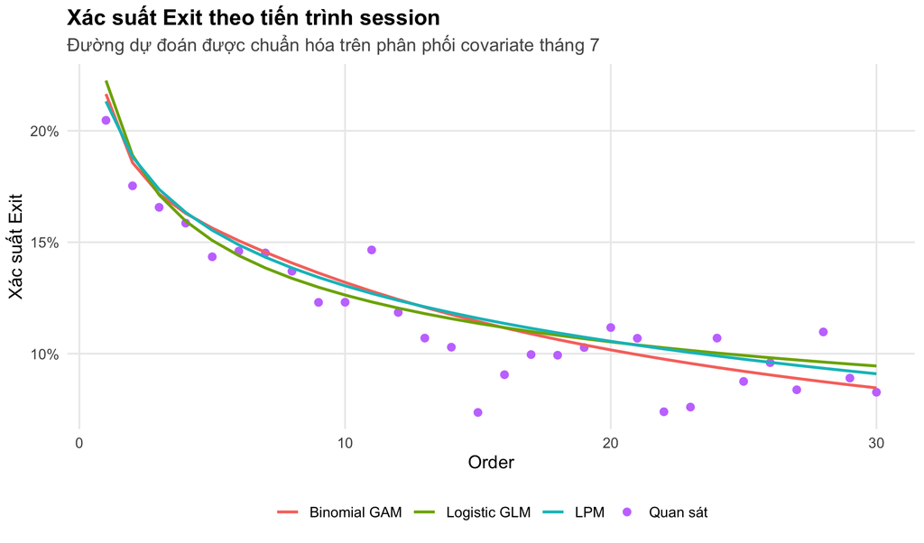

Các điểm quan sát ở phần đuôi dao động mạnh hơn vì số session còn tồn tại giảm. Sự khác biệt giữa đường GAM và hai dạng tuyến tính cho biết mức độ cần thiết của một quan hệ phi tuyến; không được diễn giải đường này như hiệu ứng nhân quả của việc tăng `order`.

### 3.2.2 Giá trị bổ sung của đặc điểm sản phẩm

Incremental gain từ baseline đến history-enhanced trên tháng 7

| Phương pháp | Tầng predictor | ROC–AUC | Average precision | Log loss | Brier | Brier skill | Calibration intercept | Calibration slope | AIC |
| --- | --- | --- | --- | --- | --- | --- | --- | --- | --- |
| LPM | Baseline | 0,589 | 0,179 | 0,406 | 0,122 | 0,010 | -0,066 | 0,899 | Không so sánh |
| LPM | Current-click | 0,611 | 0,197 | 0,405 | 0,121 | 0,016 | -0,067 | 0,808 | Không so sánh |
| LPM | History-enhanced | 0,660 | 0,233 | 0,397 | 0,119 | 0,038 | -0,060 | 0,755 | Không so sánh |
| Logistic | Baseline | 0,589 | 0,179 | 0,407 | 0,122 | 0,010 | -0,065 | 0,880 | 94998,4 |
| Logistic | Current-click | 0,611 | 0,199 | 0,403 | 0,121 | 0,016 | -0,068 | 0,873 | 94222,0 |
| Logistic | History-enhanced | 0,662 | 0,237 | 0,392 | 0,118 | 0,039 | -0,059 | 0,922 | 91801,3 |
| GAM | Baseline | 0,589 | 0,179 | 0,406 | 0,122 | 0,010 | -0,064 | 0,879 | 94957,6 |
| GAM | Current-click | 0,612 | 0,199 | 0,403 | 0,121 | 0,016 | -0,067 | 0,864 | 94160,7 |
| GAM | History-enhanced | 0,662 | 0,238 | 0,392 | 0,118 | 0,040 | -0,057 | 0,932 | 91746,6 |

Kiểm định chung nhóm `Price + Category + Colour + Location + Photography + Page` cho $p$ < 0,001 trong LPM và $p$ < 0,001 trong Logistic GLM. AIC chỉ được đọc trong cùng họ likelihood; không so sánh AIC của LPM với hai mô hình nhị phân. Sau khi đã có current-click predictors, nhóm history features bổ sung có robust joint $p$ < 0,001 trong Logistic GLM.

Mười hai nhóm biến có bằng chứng liên hệ mạnh nhất trong Logistic GLM

| Nhóm biến | Wald χ² | df | p-value | Hiệu ứng/CI 95% |
| --- | --- | --- | --- | --- |
| log2(Order) | 1081,19 | 1 | < 0,001 | OR 0,640 (0,623–0,657) |
| Số danh mục duy nhất đến hiện tại | 639,64 | 1 | < 0,001 | OR 1,562 (1,509–1,617) |
| Quay lại sản phẩm cũ | 469,92 | 1 | < 0,001 | OR 2,218 (2,064–2,384) |
| Page | 465,93 | 4 | < 0,001 | Joint test |
| Country | 150,60 | 17 | < 0,001 | Joint test |
| Chuyển Category ở click hiện tại | 75,32 | 1 | < 0,001 | OR 1,311 (1,233–1,394) |
| Colour | 93,18 | 13 | < 0,001 | Joint test |
| Chuyển Page ở click hiện tại | 46,80 | 1 | < 0,001 | OR 1,169 (1,118–1,223) |
| Category | 48,63 | 3 | < 0,001 | Joint test |
| Số sản phẩm duy nhất đến hiện tại | 40,78 | 1 | < 0,001 | OR 0,988 (0,984–0,991) |
| Location | 32,76 | 5 | < 0,001 | Joint test |
| Price (mỗi 10 USD) | 6,96 | 1 | 0,008 | OR 1,032 (1,008–1,056) |

Năm nhóm biến đứng đầu theo robust p-value và Wald statistic trên mỗi bậc tự do là: **log2(Order), Số danh mục duy nhất đến hiện tại, Quay lại sản phẩm cũ, Page, Country**. OR chỉ được trình bày khi term tương ứng đúng một hệ số; với factor nhiều mức, `Joint test` kiểm tra toàn bộ factor. Thứ hạng này phản ánh bằng chứng liên hệ, không phải mức độ quan trọng nhân quả và không nên so sánh trực tiếp độ lớn OR giữa các biến có đơn vị khác nhau.

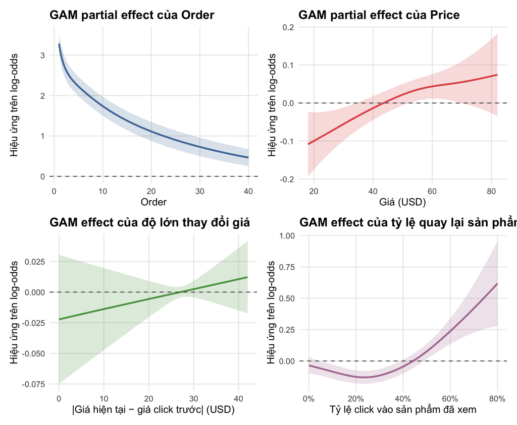

Các dải tin cậy của smooth term là khoảng tin cậy mô hình gần đúng. Do nhiều click thuộc cùng session, p-value mặc định của GAM không được dùng làm bằng chứng duy nhất. Các đồ thị được giữ để mô tả dạng hàm, nhưng chỉ được diễn giải như diagnostic nếu chẩn đoán concurvity cho thấy các term chồng lấn mạnh.

### 3.2.3 Chẩn đoán mô hình

Kiểm tra kích thước basis của GAM history-enhanced

| Smooth | k’ | edf | k-index | p-value |
| --- | --- | --- | --- | --- |
| s(log2_order) | 9,0 | 4,52 | 0,934 | 0,170 |
| s(price) | 7,0 | 1,88 | 0,943 | 0,350 |
| s(repeat_rate) | 7,0 | 3,20 | 0,950 | 0,580 |
| s(abs_price_delta_10) | 7,0 | 1,01 | 0,947 | 0,362 |

Mười GVIF điều chỉnh lớn nhất của Logistic GLM

| Term | GVIF điều chỉnh |
| --- | --- |
| log2_order | 2,424 |
| unique_products | 2,022 |
| price_vs_prior_mean_10 | 1,989 |
| unique_categories | 1,944 |
| price_10 | 1,729 |
| price_delta_10 | 1,688 |
| category_switch_rate | 1,627 |
| repeat_rate | 1,497 |
| category_switch | 1,442 |
| repeat_current | 1,441 |

Năm cặp term có concurvity cao nhất trong GAM

| Term được giải thích | Term còn lại | Concurvity |
| --- | --- | --- |
| s(log2_order) | para | 0,994 |
| s(abs_price_delta_10) | para | 0,966 |
| s(repeat_rate) | para | 0,866 |
| s(log2_order) | s(repeat_rate) | 0,802 |
| para | s(repeat_rate) | 0,769 |

Concurvity lớn nhất giữa các term của GAM là 0,994. K-index được đọc cùng edf; một p-value nhỏ chỉ đáng lo khi edf đồng thời tiến sát giới hạn basis. Bảng cặp term giúp phân biệt concurvity do các biểu diễn chồng lấn của tiến trình session với vấn đề thiếu basis. `s(unique_products)` đã được loại khỏi GAM vì gần trùng thông tin với `Order` và `repeat_rate`; `unique_products` vẫn được giữ trong Logistic GLM, nơi GVIF điều chỉnh còn thấp. Vì concurvity sau rút gọn vẫn ở mức gần xác định, các partial-effect plot của GAM không được diễn giải như hiệu ứng riêng biệt; GAM chỉ được giữ làm đối chứng dự báo phi tuyến.

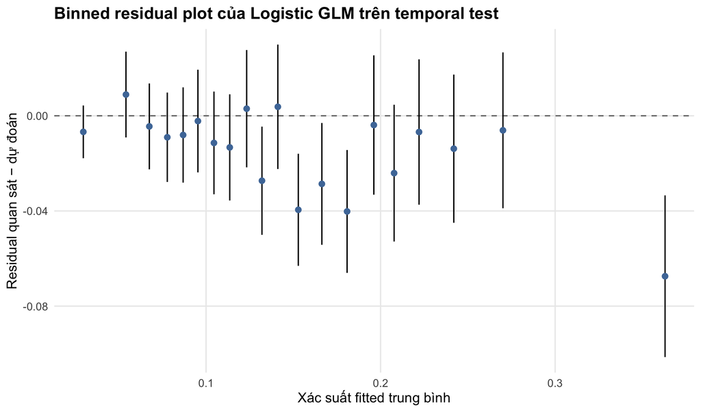

## 3.3 So sánh khả năng dự đoán và phân loại

### 3.3.1 Các metric được sử dụng

Với quan sát $i=1,\ldots,n$, ký hiệu $y_i\in\{0,1\}$ là nhãn `Exit` thực tế và $\hat p_i=P(Y_i=1\mid X_i)$ là xác suất do mô hình dự đoán. Báo cáo đánh giá hai khía cạnh khác nhau: **chất lượng xác suất** và **chất lượng phân loại sau khi chọn threshold**.

**Metric không phụ thuộc threshold**

- **ROC–AUC** là diện tích dưới đường ROC, trong đó $\operatorname{TPR}(t)=P(\hat p\geq t\mid Y=1)$ và $\operatorname{FPR}(t)=P(\hat p\geq t\mid Y=0)$. Tương đương,
  $$\operatorname{AUC}
  =P(\hat p_{+}>\hat p_{-})+\tfrac12P(\hat p_{+}=\hat p_{-}).$$
  AUC bằng 0,5 tương ứng xếp hạng ngẫu nhiên; càng gần 1 càng tốt. Metric này đo khả năng xếp hạng nhưng không cho biết xác suất có được hiệu chỉnh tốt hay không.
- **Average Precision (AP)** tóm tắt đường Precision–Recall:
  $$\operatorname{AP}
  =\sum_k (R_k-R_{k-1})P_k,$$
  với $P_k$ và $R_k$ lần lượt là precision và recall tại threshold thứ $k$. AP càng cao càng tốt; mốc tham chiếu của mô hình ngẫu nhiên xấp xỉ prevalence của `Exit`. Vì lớp `Exit = 1` ít hơn, AP được báo cáo cùng AUC để tránh chỉ nhìn một metric có thể trông lạc quan khi dữ liệu mất cân bằng.
- **Log loss** đánh giá trực tiếp xác suất dự đoán:
  $$-\frac{1}{n}\sum_{i=1}^{n}
  \left[y_i\log(\hat p_i)+(1-y_i)\log(1-\hat p_i)\right].$$
  Giá trị càng nhỏ càng tốt và phạt rất mạnh các dự đoán tự tin nhưng sai.
- **Brier score** là sai số bình phương trung bình của xác suất:
  $$\operatorname{Brier}
  =\frac{1}{n}\sum_{i=1}^{n}(\hat p_i-y_i)^2.$$
  Giá trị càng nhỏ càng tốt. **Brier Skill Score** so sánh mô hình với dự báo hằng bằng prevalence trên tập train:
  $$\operatorname{BSS}
  =1-\frac{\operatorname{Brier}_{model}}
  {\operatorname{Brier}_{reference}}.$$
  BSS $>0$ nghĩa là tốt hơn mô hình tham chiếu, bằng 0 là tương đương và $<0$ là kém hơn.
- **Calibration intercept và slope** được ước lượng từ
  $$\operatorname{logit}\{P(Y=1)\}
  =\alpha+\beta\,\operatorname{logit}(\hat p).$$
  Mô hình hiệu chỉnh lý tưởng có $\alpha=0$ và $\beta=1$. Intercept âm cho thấy mô hình có xu hướng dự đoán xác suất quá cao; slope nhỏ hơn 1 thường cho thấy dự đoán quá cực đoan hoặc có overfitting.

**Metric phụ thuộc threshold**

Sau khi chọn threshold $t$, dự đoán dương khi $\hat p_i\geq t$. Gọi $TP,TN,FP,FN$ lần lượt là số dương đúng, âm đúng, dương giả và âm giả:

$$\begin{aligned}
\operatorname{Accuracy} &= \frac{TP+TN}{TP+TN+FP+FN},\\
\operatorname{Precision} &= \frac{TP}{TP+FP},\\
\operatorname{Recall\ (Sensitivity)} &= \frac{TP}{TP+FN},\\
\operatorname{Specificity} &= \frac{TN}{TN+FP},\\
F_1 &= 2\frac{\operatorname{Precision}\times\operatorname{Recall}}
{\operatorname{Precision}+\operatorname{Recall}}.
\end{aligned}$$

Threshold của từng mô hình được chọn bằng cách tối đa hóa $F_1$ trên prediction out-of-fold của tập train, rồi được khóa trước validation tháng 7 và temporal test tháng 8. Vì dữ liệu mất cân bằng, Accuracy không được dùng để chọn mô hình. Trên validation, các mô hình nằm trong 1% log loss tốt nhất rồi 1% Brier tốt nhất được xem là gần tương đương; khi còn nhiều ứng viên, ưu tiên Logistic GLM vì đơn giản và dễ diễn giải hơn GAM, còn LPM chỉ là benchmark. Các metric threshold chỉ mô tả hành vi vận hành tại ngưỡng đã chọn.

Hiệu năng cuối của ba mô hình trên temporal test 01–12/08

| Model | ROC–AUC (CI 95%) | Average precision (CI 95%) | Log loss (CI 95%) | Brier skill | Brier (CI 95%) | Calibration intercept | Calibration slope | Ngoài [0,1] |
| --- | --- | --- | --- | --- | --- | --- | --- | --- |
| LPM | 0,662 (0,644–0,681) | 0,224 (0,212–0,241) | 0,382 (0,363–0,399) | 0,036 | 0,114 (0,107–0,120) | -0,138 | 0,868 | 1,706% |
| Logistic GLM | 0,666 (0,647–0,685) | 0,230 (0,218–0,246) | 0,379 (0,361–0,396) | 0,039 | 0,113 (0,107–0,119) | -0,127 | 0,934 | 0,000% |
| Binomial GAM | 0,666 (0,647–0,686) | 0,230 (0,218–0,247) | 0,379 (0,361–0,396) | 0,039 | 0,113 (0,107–0,119) | -0,125 | 0,942 | 0,000% |

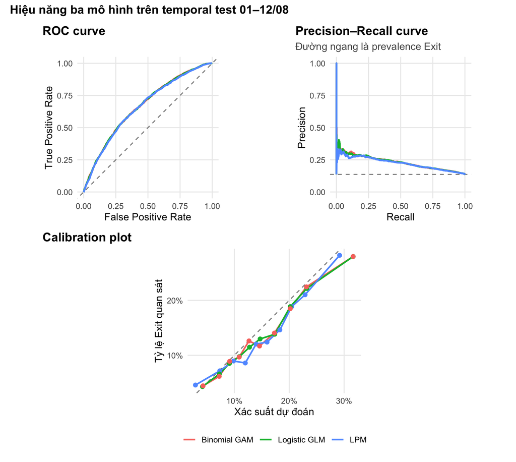

ROC–AUC đo khả năng xếp hạng, trong khi log loss, Brier và calibration đánh giá độ lớn của xác suất. Average precision được đọc so với prevalence `Exit` vì ROC có thể quá lạc quan khi lớp dương ít hơn. Brier skill dương nghĩa là mô hình tốt hơn dự báo hằng bằng prevalence train. Accuracy không được dùng làm tiêu chí chính.

Metric phân loại temporal test tại threshold chọn từ grouped OOF train

| Model | Threshold | TP | TN | FP | FN | Accuracy | Precision | Recall | Specificity | F1 |
| --- | --- | --- | --- | --- | --- | --- | --- | --- | --- | --- |
| LPM | 0,168 | 1.176 | 7.428 | 4.617 | 727 | 61,69% | 20,30% | 61,80% | 61,67% | 30,56% |
| Logistic GLM | 0,162 | 1.145 | 7.722 | 4.323 | 758 | 63,57% | 20,94% | 60,17% | 64,11% | 31,07% |
| Binomial GAM | 0,163 | 1.123 | 7.843 | 4.202 | 780 | 64,28% | 21,09% | 59,01% | 65,11% | 31,07% |

Metric validation tháng 7 dùng trong lựa chọn mô hình

| Model | ROC–AUC | Average precision | Log loss | Brier | Brier skill | Calibration intercept | Calibration slope |
| --- | --- | --- | --- | --- | --- | --- | --- |
| LPM | 0,660 | 0,233 | 0,397 | 0,119 | 0,038 | -0,060 | 0,755 |
| Logistic GLM | 0,662 | 0,237 | 0,392 | 0,118 | 0,039 | -0,059 | 0,922 |
| Binomial GAM | 0,662 | 0,238 | 0,392 | 0,118 | 0,040 | -0,057 | 0,932 |

Hiệu năng phân tầng của Logistic GLM trên temporal test 01–12/08

| Phân tầng | Nhóm | N | Prevalence | ROC–AUC | Average precision | Log loss | Brier |
| --- | --- | --- | --- | --- | --- | --- | --- |
| Category | Trousers | 4.067 | 12,59% | 0,638 | 0,200 | 0,365 | 0,107 |
| Category | Skirts | 2.769 | 15,57% | 0,632 | 0,216 | 0,420 | 0,129 |
| Category | Blouses | 3.205 | 13,92% | 0,688 | 0,252 | 0,380 | 0,114 |
| Category | Sale | 3.907 | 13,16% | 0,693 | 0,252 | 0,364 | 0,108 |
| Order | 1–2 | 3.437 | 18,10% | 0,612 | 0,241 | 0,465 | 0,146 |
| Order | 3–4 | 2.357 | 15,27% | 0,616 | 0,233 | 0,418 | 0,127 |
| Order | 5–7 | 2.395 | 13,70% | 0,631 | 0,213 | 0,388 | 0,116 |
| Order | 8–12 | 2.273 | 13,33% | 0,664 | 0,261 | 0,370 | 0,110 |
| Order | 13–20 | 1.653 | 9,13% | 0,670 | 0,198 | 0,292 | 0,080 |
| Order | >20 | 1.833 | 7,58% | 0,723 | 0,187 | 0,245 | 0,066 |

Theo quy tắc lựa chọn đã xác định trước, mô hình được chọn trên validation là **Logistic GLM**. Các ứng viên trong ngưỡng 1% của log loss và Brier được xem là gần tương đương; Logistic GLM được ưu tiên vì đơn giản và dễ diễn giải hơn. Temporal test chỉ dùng để báo cáo khả năng khái quát hóa sau quyết định này.

# 4 Nhận xét và kết luận

## 4.1 Kết quả chính

Tháng 7 cho thấy nhóm sản phẩm có giá cao hơn trung bình danh mục có tỷ lệ `Exit` cao hơn nhóm còn lại khoảng 1,19 điểm phần trăm; adjusted risk difference là 0,82 điểm phần trăm. Hướng khác biệt lặp lại trong train và đầu tháng 8. Interaction test theo Category có $p$ 0,051, cho thấy hiệu ứng gộp không nhất thiết đại diện đồng đều cho mọi danh mục. Đây là bằng chứng về một mối liên hệ dự báo, không phải bằng chứng rằng giá cao gây kết thúc session.

Các mô hình current-click kiểm tra xem đặc điểm sản phẩm có bổ sung thông tin ngoài `Order`, thời gian và country. Nhóm history features tiếp tục cải thiện Logistic GLM: ROC–AUC tăng 0,050 và log loss giảm 0,012 trên tháng 7. Robust joint test của history features có $p$ < 0,001. Kết quả này cho thấy hành vi đã diễn ra trong session chứa tín hiệu mà chỉ nhìn click hiện tại sẽ bỏ sót. Bằng chứng liên hệ mạnh nhất trong Logistic GLM tập trung ở log2(Order), Số danh mục duy nhất đến hiện tại, Quay lại sản phẩm cũ, Page, Country; đây là xếp hạng liên hệ dự báo, không phải thứ hạng tác động nhân quả.

Trên validation tháng 7, **Logistic GLM** nằm trong nhóm gần tương đương về log loss và Brier, rồi được chọn vì đơn giản và dễ diễn giải. Temporal test 01–12/08 chỉ được mở để đánh giá sau lựa chọn và không dùng để tối ưu lại mô hình. Dù được cải thiện, khả năng phân biệt vẫn ở mức trung bình và chưa đủ để xem là một hệ thống triển khai sẵn.

## 4.2 Hàm ý thực tiễn

- `Order` và các xác suất chuẩn hóa có thể dùng để nhận diện giai đoạn session cần ưu tiên hỗ trợ, nhưng không nên xem `Order` là một can thiệp.
- Số sản phẩm đã xem, hành vi quay lại sản phẩm và chuyển đổi giữa các danh mục có thể được cập nhật theo thời gian thực mà không cần biết tương lai của session.
- Nhóm giá cao hơn trung bình có thể là một tín hiệu bổ sung trong hệ thống dự báo. Trước khi thay đổi chính sách giá hoặc giao diện, cần một thí nghiệm ngẫu nhiên thực sự, chẳng hạn thử thông điệp giá trị, ưu đãi vận chuyển hoặc cách trình bày thông tin giá.
- Nếu triển khai dự báo, cần theo dõi cả calibration theo thời gian; AUC tốt không bảo đảm xác suất dự đoán đúng về độ lớn.

## 4.3 Hạn chế

- Không có treatment/control ngẫu nhiên; phân tích hai nhóm giá là quan sát và chịu confounding bởi sản phẩm, danh mục và hành vi duyệt.
- Giả thuyết nhóm giá được định hướng từ EDA; p-value cần được đọc cùng effect size, balance diagnostics, kiểm tra theo thời gian và Holm correction.
- Không có thông tin mua hàng, giỏ hàng, thanh toán, user ID dài hạn, giờ click hoặc thời lượng giữa click.
- Nhiều click trong cùng session phụ thuộc nhau; robust SE và bootstrap theo session chỉ xử lý một phần vấn đề.
- Tháng 8 không đầy đủ và ngày 13/08 có dấu hiệu thu thập dở dang.
- Tại mỗi `Order`, chỉ các session sống sót đến vị trí đó được quan sát; quan hệ theo tiến trình chịu selection của session còn tồn tại.
- Dữ liệu từ năm 2008 và một e-shop cụ thể; cần đánh giá lại trước khi áp dụng cho môi trường hiện tại.